# 01-Roulette-Simulation

### **First let’s understand what is Martingale System?**

The roulette has total of 38 even sized slots, 18 of which are red, 18 are black and rest 2 are green. Martingale System suggests that puts yours odds on black starting with $1 and if the ball lands on black then you will make additional $1 but if it lands on red then you will loose your bet money. Martingale suggested to double your bet each time such that if you llst all tge previous one and you won the current one you will end with $1 in profit.  
This technique seems lucrative to those who never played this game or atlest they will think that atleast they will not end up in loss if they just won 1 bet after many looses.

#### **Problems with this technique:**

- **The odds :** There is a possibility that the ball land on green as there are 2 green spots on the table. Both balck and red can loose if the ball lands on 0 or green spot.
- **The Limits:** All the tables in casinos have betting limit which means that if your luck is on the loosing side and you reach the table betting limit then casino will stop from doubling your bet. Also no one has infinie money in their bank account.
- **Math:** This technique will help anyone alot but the profits will not be huge. Think of it this way : you may have few loosing sessions but the looses will be enoromous which will cancel out the winning sessions.

#### **Limitation of Simulation:**

We need more samples to be sure about the distribution of the data but pc is computationally constaraint to cpu limitations. We would be needing infinite samples but that is not possible on PC.  
Simulations are often not precise. Lack of prexision is difficult to measure.  
It’s a trial and error method that may produce different solutions in different run.

#### **Simulation**

##### **Parameters :**

Param B: the starting budget  
Param W: the budget threshold for successfully stoping  
Param L: the maximum number of plays  
Param M: the casino wager limit  
Return A : vector of budget values calculated after each play.

#### **Simulation 1:**

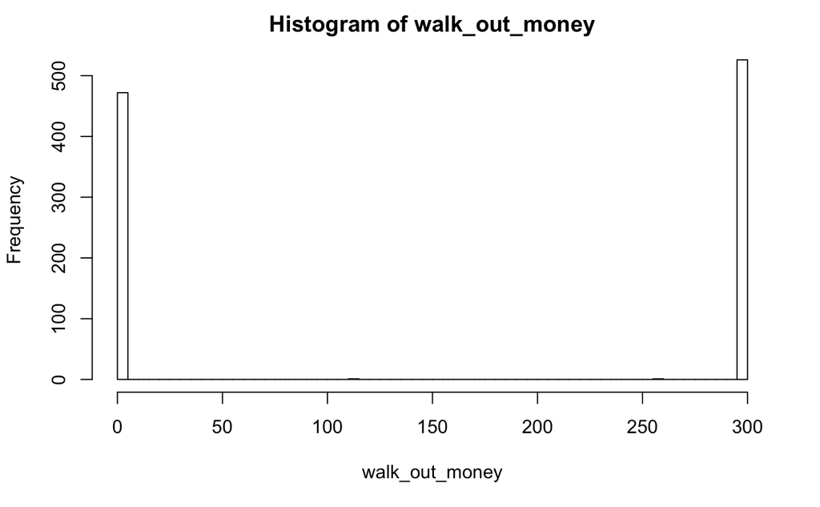

```r
walk_out_money <- rep(NA, 1000)
for(j in seq_along(walk_out_money)){
  walk_out_money[j] <- one_series(B = 200, W = 300, L = 1000, M = 100) %>% get_last
}

# Walk out money distribution
hist(walk_out_money, breaks = 100)

# Estimated probability of walking out with extra cash
mean(walk_out_money > 200)
```

```
[1] 0.527
```

```r
# Estimated earnings
mean(walk_out_money - 200)
```

```
[1] -41.828
```

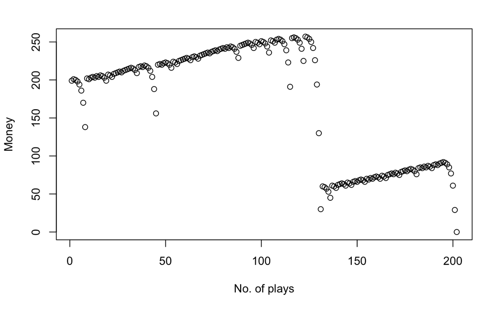

```r
plot(one_series(B = 200, W = 300, L = 1000, M = 100),ylab = "Money",xlab = "No. of plays")
```

In the above simulation we had set our parameters to be as follows:  
B = 200 ; W = 300 ; L = 1000 ; M = 100  
After running the simulation we find that chance of our winning is 0.527 with average walk out money of -41.8 dollars. As we can see from the second plot above we do end up with $50 in profit after around 100 plays but if we increased our number of play we tend to loose money. I ran this simulation multiple time and every time I end up with different results as we need more samples but our computation power is limited. Anyways, what the plot above tells us that we have chance of winning around 0.52 with average walk out money of -41.8 dollars.

##### **As a data scientist we should have curosity to ask that what will happen if I change the parameters. Is there a connection between the parameters. Let’s find out…**

#### **Simulation 2:**

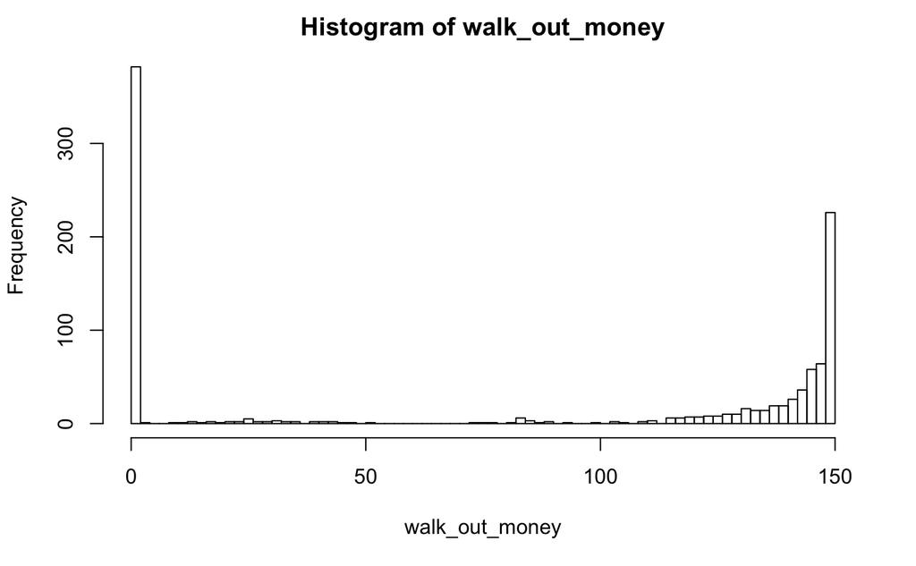

```r
# Simulation 2
walk_out_money <- rep(NA, 1000)
for(j in seq_along(walk_out_money)){
  walk_out_money[j] <- one_series(B = 100, W = 150, L = 100, M = 1000) %>% get_last
}

# Walk out money distribution
hist(walk_out_money, breaks = 100)
```

```r
# Estimated probability of walking out with extra cash
mean(walk_out_money > 100)
```

```
[1] 0.562
```

```r
# Estimated earnings
mean(walk_out_money - 100)
```

```
[1] -17.143
```

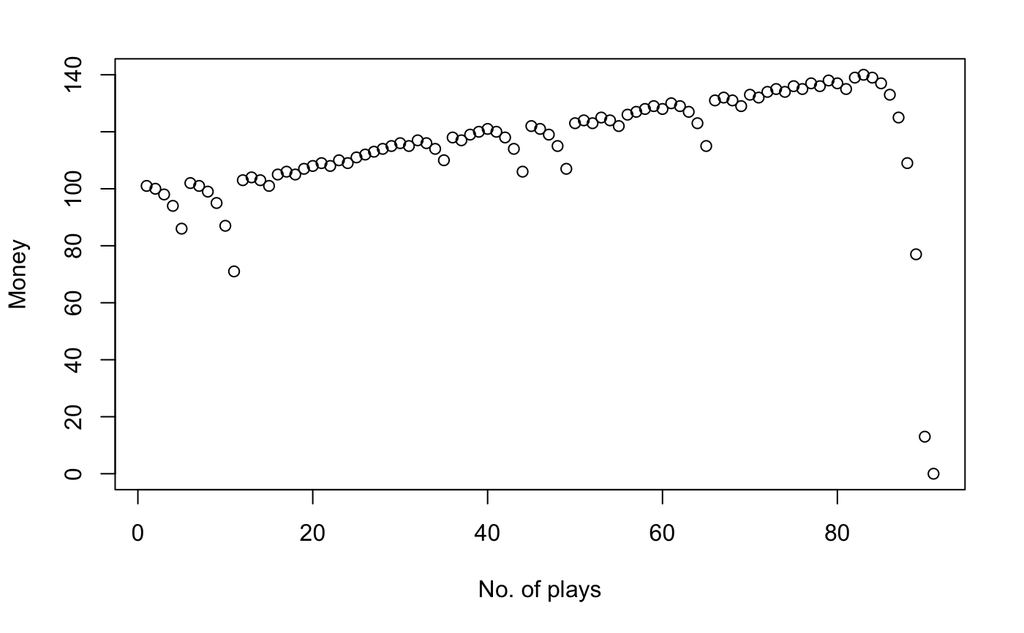

```r
plot(one_series(B = 100, W = 150, L = 100, M = 1000),ylab = "Money",xlab = "No. of plays")
```

#### **Simulation 3:**

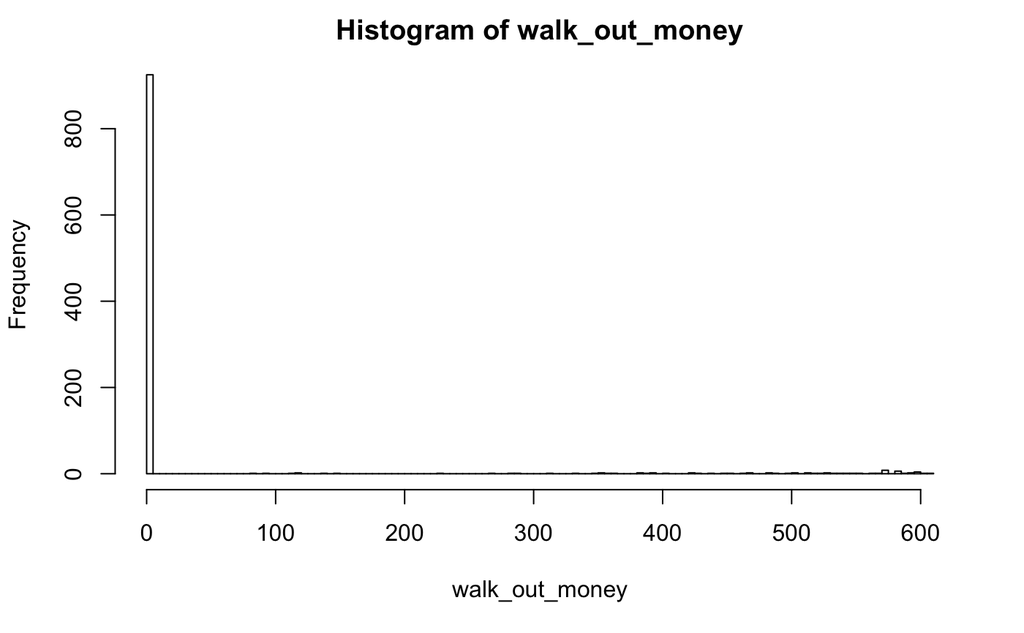

```r
# Simulation 3
walk_out_money <- rep(NA, 1000)
for(j in seq_along(walk_out_money)){
  walk_out_money[j] <- one_series(B = 100, W = 10000, L = 1000, M = 1000) %>% get_last
}

# Walk out money distribution
hist(walk_out_money, breaks = 100)
```

```r
# Estimated probability of walking out with extra cash
mean(walk_out_money > 1000)
```

```
[1] 0
```

```r
# Estimated earnings
mean(walk_out_money - 1000)
```

```
[1] -965.961
```

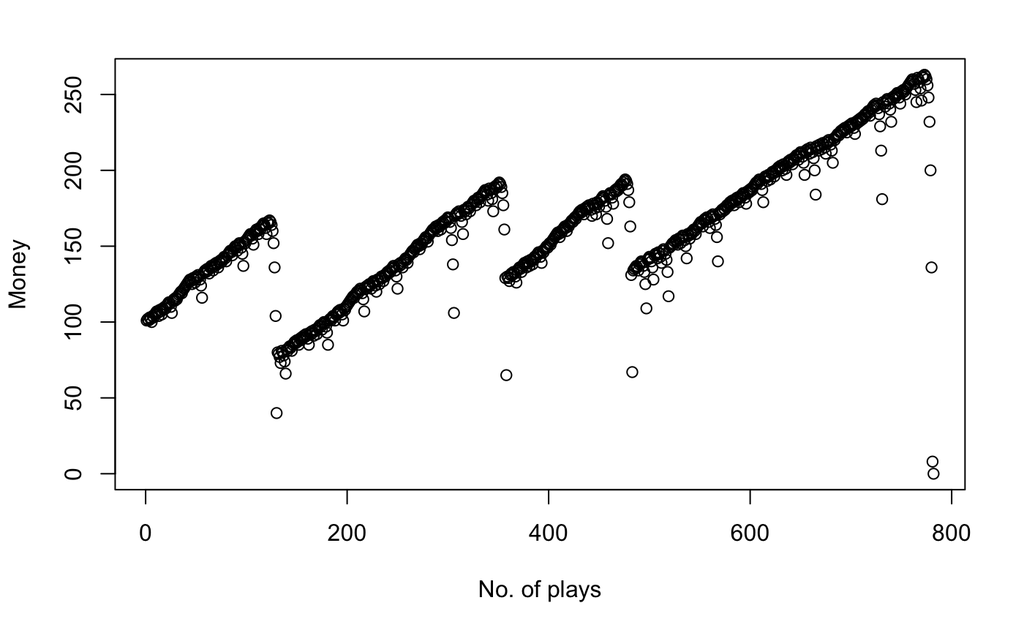

```r
plot(one_series(B = 100, W = 10000, L = 1000, M = 1000),ylab = "Money",xlab = "No. of plays")
```

#### **Simulation 4:**

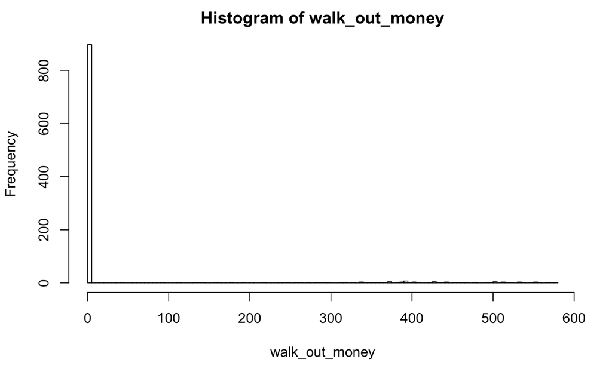

```r
# Simulation 4
walk_out_money <- rep(NA, 1000)
for(j in seq_along(walk_out_money)){
  walk_out_money[j] <- one_series(B = 100, W = 1000, L = 1000, M = 100) %>% get_last
}

# Walk out money distribution
hist(walk_out_money, breaks = 100)
```

```r
# Estimated probability of walking out with extra cash
mean(walk_out_money > 100)
```

```
[1] 0.101
```

```r
# Estimated earnings
mean(walk_out_money - 100)
```

```
[1] -60.232
```

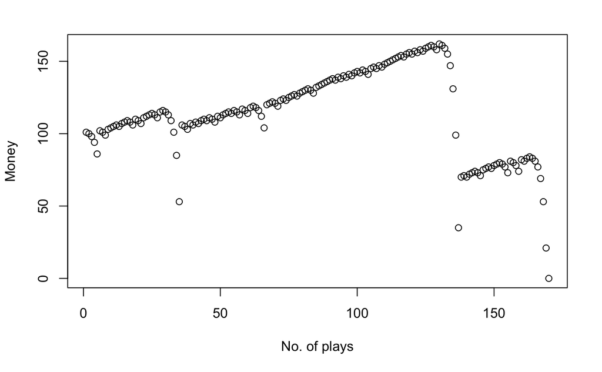

```r
plot(one_series(B = 100, W = 1000, L = 1000, M = 100),ylab = "Money",xlab = "No. of plays")
```

In the above simulation we had set our parameters to be as follows:  
B = 100 ; W = 1000 ; L = 1000 ; M = 100

#### **Simulation 5:**

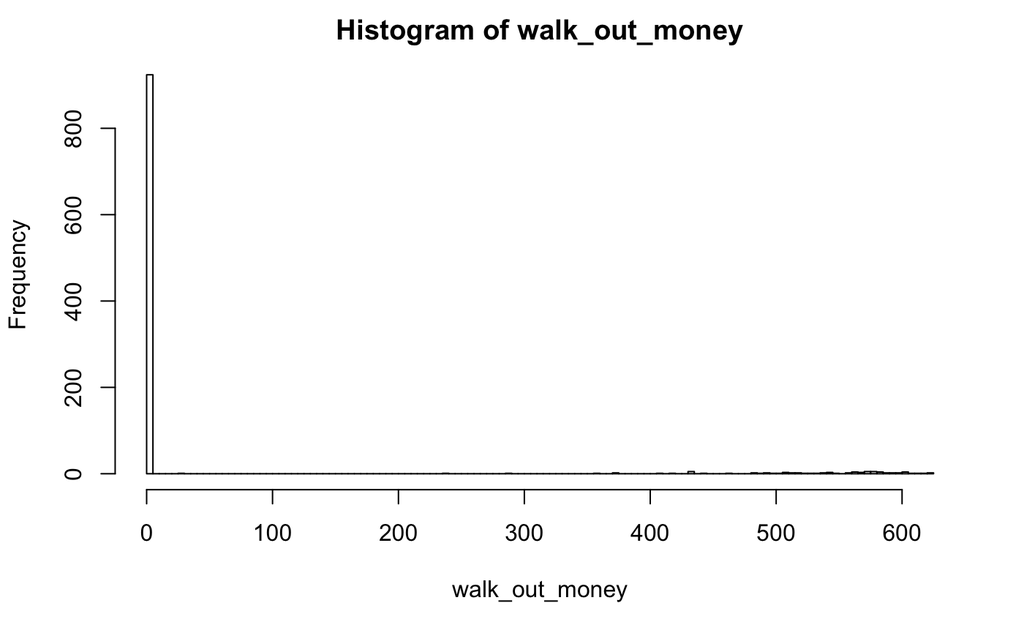

```r
# Simulation 5
walk_out_money <- rep(NA, 1000)
for(j in seq_along(walk_out_money)){
  walk_out_money[j] <- one_series(B = 100, W = 1000, L = 1000, M = 1000) %>% get_last
}

# Walk out money distribution
hist(walk_out_money, breaks = 100)
```

```r
# Estimated probability of walking out with extra cash
mean(walk_out_money > 100)
```

```
[1] 0.075
```

```r
# Estimated earnings
mean(walk_out_money - 100)
```

```
[1] -60.347
```

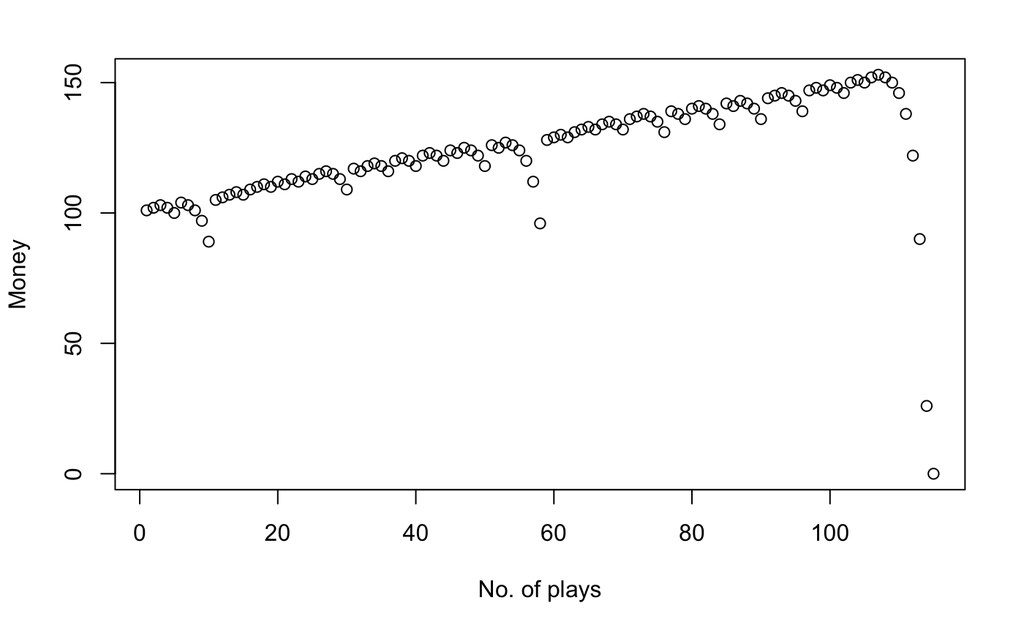

```r
plot(one_series(B = 100, W = 1000, L = 1000, M = 1000),ylab = "Money",xlab = "No. of plays")
```

In the above simulation we had set our parameters to be as follows:  
B = 100 ; W = 1000 ; L = 1000 ; M = 1000

#### **Simulation 6:**

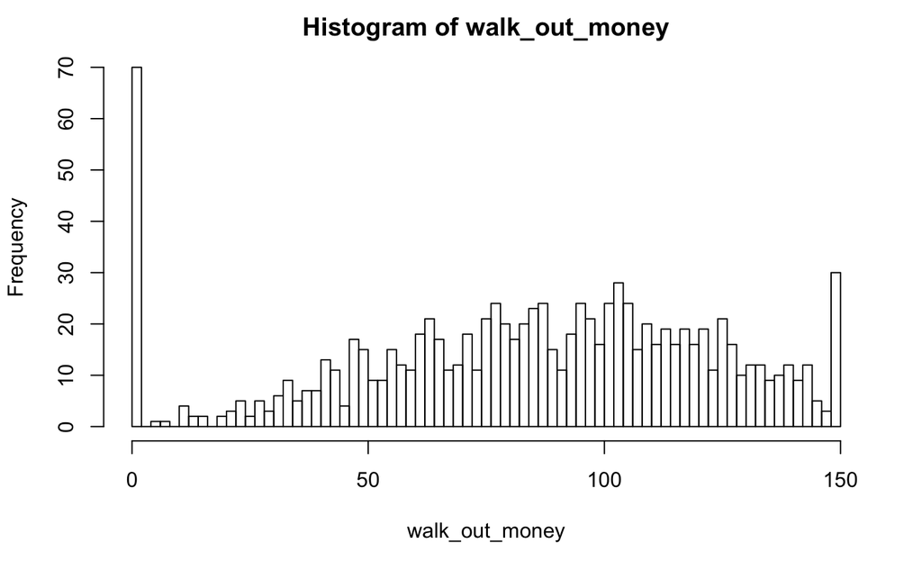

```r
# Simulation 6
walk_out_money <- rep(NA, 1000)
for(j in seq_along(walk_out_money)){
  walk_out_money[j] <- one_series(B = 100, W = 150, L = 100, M = 10) %>% get_last
}

# Walk out money distribution
hist(walk_out_money, breaks = 100)
```

```r
# Estimated probability of walking out with extra cash
mean(walk_out_money > 100)
```

```
[1] 0.388
```

```r
# Estimated earnings
mean(walk_out_money - 100)
```

```
[1] -15.605
```

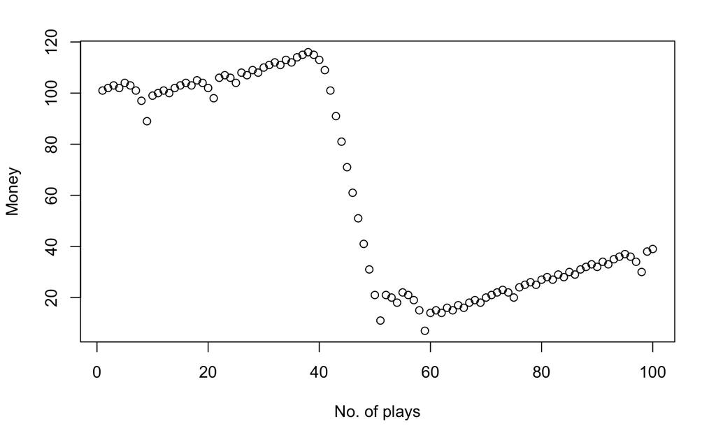

```r
plot(one_series(B = 100, W = 150, L = 100, M = 10),ylab = "Money",xlab = "No. of plays")
```

In the above simulation we had set our parameters to be as follows:  
B = 100 ; W = 150 ; L = 100 ; M = 10

#### **Simulation 7:**

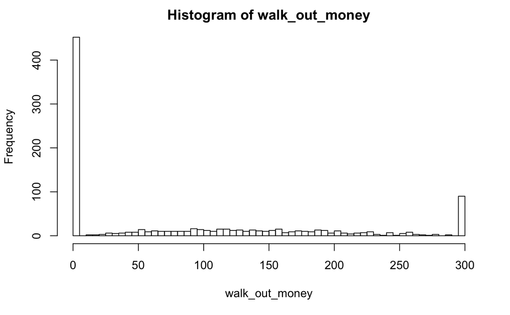

```r
# Simulation 7
walk_out_money <- rep(NA, 1000)
for(j in seq_along(walk_out_money)){
  walk_out_money[j] <- one_series(B = 200, W = 300, L = 1000, M = 10) %>% get_last
}

# Walk out money distribution
hist(walk_out_money, breaks = 100)
```

```r
# Estimated probability of walking out with extra cash
mean(walk_out_money > 200)
```

```
[1] 0.169
```

```r
# Estimated earnings
mean(walk_out_money - 200)
```

```
[1] -111.124
```

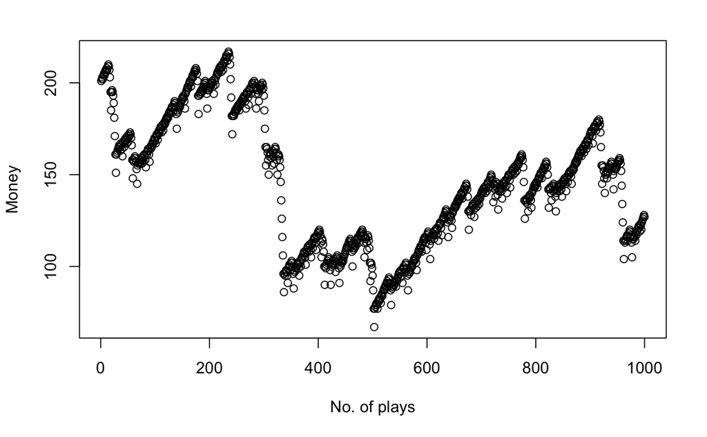

```r
plot(one_series(B = 200, W = 300, L = 1000, M = 10),ylab = "Money",xlab = "No. of plays")
```

In the above simulation we had set our parameters to be as follows:  
B = 200 ; W = 300 ; L = 1000 ; M = 10

#### **Simulation 8:**

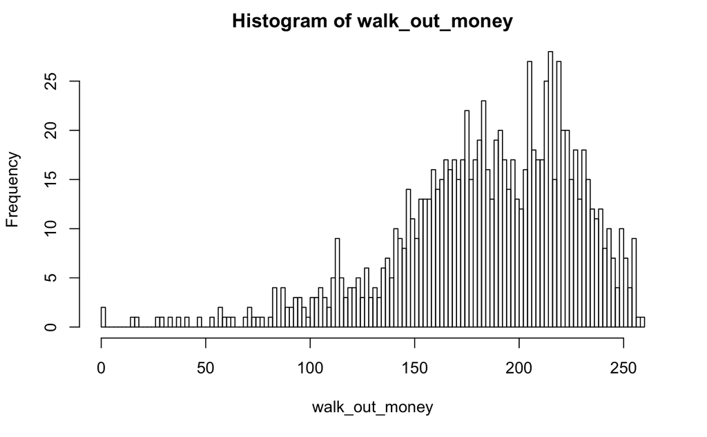

```r
# Simulation 8
walk_out_money <- rep(NA, 1000)
for(j in seq_along(walk_out_money)){
  walk_out_money[j] <- one_series(B = 200, W = 300, L = 100, M = 10) %>% get_last
}

# Walk out money distribution
hist(walk_out_money, breaks = 100)
```

```r
# Estimated probability of walking out with extra cash
mean(walk_out_money > 200)
```

```
[1] 0.417
```

```r
# Estimated earnings
mean(walk_out_money - 200)
```

```
[1] -14.952
```

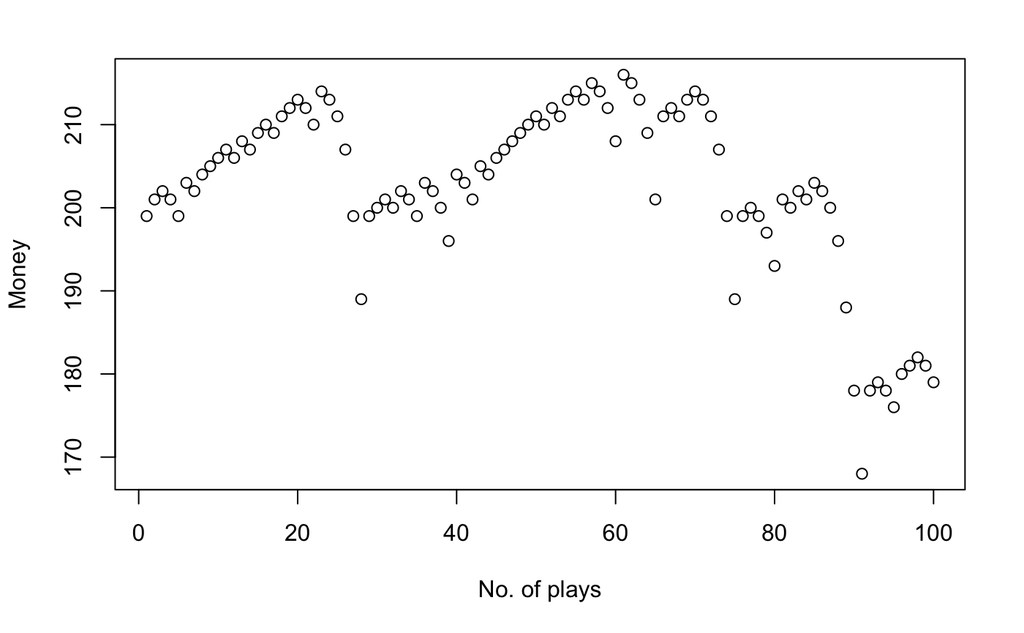

```r
plot(one_series(B = 200, W = 300, L = 100, M = 10),ylab = "Money",xlab = "No. of plays")
```

In the above simulation we had set our parameters to be as follows:  
B = 200 ; W = 300 ; L = 100 ; M = 10

#### **Conclusions :**

So we infer from the above graphs that there is no chance if you are going with a small budget and expecting that your money is gonna get increase by almost 1000%. This strategy is not your best bet then.

Throughtout the simulation our earnings remained negative which tells us that this strategy is not the best strategy out there.

We do infer one thing that there is an relation between parameters. We found out that if are going wit less budget and expecting less profit with less number number of plays with high wager limit by casino then probability of winning is the highest, i.e. 0.562

Overall, this strategy is not your bet to the path to riches. There are many strategies which can be simulated the same way as we did this and can find out which is the best to play with.